# Part I - Prosper Loan Data Analysis And Exploration

## Introduction

This data set contains 113,937 loans with 81 variables on each loan, including loan amount, borrower rate (or interest rate), current loan status, borrower income, and many others.

This data [dictionary](https://docs.google.com/spreadsheets/d/1gDyi_L4UvIrLTEC6Wri5nbaMmkGmLQBk-Yx3z0XDEtI/edit#gid=0) explains the variables in the data set.

## Preliminary Wrangling

```python
# import all packages and set plots to be embedded inline
import numpy as np
import pandas as pd
import matplotlib.pyplot as plt
import seaborn as sb
import warnings

warnings.filterwarnings('ignore')
%matplotlib inline
```

```python
pd.set_option('display.max_columns', None)
prosper = pd.read_csv('prosperLoanData.csv')
```

```python
prosper.shape
```

```
(113937, 81)
```

```python
prosper.sample(15)
```

|  | ListingKey | ListingNumber | ListingCreationDate | CreditGrade | Term | LoanStatus | ClosedDate | BorrowerAPR | BorrowerRate | LenderYield | EstimatedEffectiveYield | EstimatedLoss | EstimatedReturn | ProsperRating (numeric) | ProsperRating (Alpha) | ProsperScore | ListingCategory (numeric) | BorrowerState | Occupation | EmploymentStatus | EmploymentStatusDuration | IsBorrowerHomeowner | CurrentlyInGroup | GroupKey | DateCreditPulled | CreditScoreRangeLower | CreditScoreRangeUpper | FirstRecordedCreditLine | CurrentCreditLines | … |
| --- | --- | --- | --- | --- | --- | --- | --- | --- | --- | --- | --- | --- | --- | --- | --- | --- | --- | --- | --- | --- | --- | --- | --- | --- | --- | --- | --- | --- | --- | --- |
| 89480 | 3D273577760117444046390 | 758851 | 2013-04-22 17:46:45.357000000 | NaN | 36 | Current | NaN | 0.30285 | 0.2639 | 0.2539 | 0.23180 | 0.1225 | 0.10930 | 2.0 | E | 3.0 | 7 | CO | Postal Service | Self-employed | 144.0 | False | False | NaN | 2013-04-22 17:46:38 | 640.0 | 659.0 | 1994-08-25 00:00:00 | 11.0 | … |
| 112732 | DCF43390934210404C491CC | 141264 | 2007-05-22 09:04:52.537000000 | C | 36 | Completed | 2008-02-05 00:00:00 | 0.23748 | 0.2300 | 0.2150 | NaN | NaN | NaN | NaN | NaN | NaN | 0 | CA | Other | Full-time | 151.0 | True | True | 223133764057631067F3FD8 | 2007-05-22 08:50:34.420000000 | 640.0 | 659.0 | 1990-04-04 00:00:00 | 4.0 | … |
| 93180 | 27DD35997137515789BE196 | 1119204 | 2014-01-06 16:36:45.353000000 | NaN | 36 | Current | NaN | 0.08496 | 0.0716 | 0.0616 | 0.06044 | 0.0149 | 0.04554 | 7.0 | AA | 6.0 | 8 | CA | Teacher | Employed | 4.0 | False | False | NaN | 2014-01-06 16:36:47 | 800.0 | 819.0 | 1998-10-12 00:00:00 | 3.0 | … |
| 10038 | 0BEB3550327391525B87E62 | 604409 | 2012-06-26 07:50:00.583000000 | NaN | 60 | Current | NaN | 0.35838 | 0.3304 | 0.3204 | 0.30570 | 0.1470 | 0.15870 | 2.0 | E | 8.0 | 2 | GA | Administrative Assistant | Employed | 29.0 | False | False | NaN | 2012-06-22 20:42:16 | 640.0 | 659.0 | 2007-08-10 00:00:00 | 8.0 | … |
| 49482 | A36F350385667189483728C | 488622 | 2010-12-21 12:01:52.080000000 | NaN | 36 | Completed | 2013-06-25 00:00:00 | 0.15549 | 0.1340 | 0.1240 | 0.12190 | 0.0495 | 0.07240 | 5.0 | B | 8.0 | 1 | NM | Professional | Full-time | 342.0 | True | False | NaN | 2010-12-21 12:01:40 | 760.0 | 779.0 | 1983-04-29 00:00:00 | 22.0 | … |
| 104090 | 753D355562623295003F17C | 624131 | 2012-08-14 09:54:19.770000000 | NaN | 36 | Completed | 2013-04-01 00:00:00 | 0.21025 | 0.1734 | 0.1634 | 0.15970 | 0.0624 | 0.09730 | 4.0 | C | 5.0 | 7 | VA | Sales - Commission | Employed | 12.0 | True | False | NaN | 2012-08-14 09:54:15 | 700.0 | 719.0 | 1993-11-01 00:00:00 | 5.0 | … |
| 13068 | 05CF35578116867349BD9D8 | 635633 | 2012-09-07 15:08:24.693000000 | NaN | 36 | Current | NaN | 0.35797 | 0.3177 | 0.3077 | 0.28960 | 0.1675 | 0.12210 | 1.0 | HR | 4.0 | 15 | MD | Clerical | Employed | 24.0 | False | False | NaN | 2012-09-07 15:08:23 | 660.0 | 679.0 | 1995-09-06 00:00:00 | 1.0 | … |
| 91714 | F99D33654385050461CB607 | 30569 | 2006-08-10 21:14:00.367000000 | A | 36 | Completed | 2009-08-21 00:00:00 | 0.10692 | 0.1000 | 0.0950 | NaN | NaN | NaN | NaN | NaN | NaN | 0 | IL | Professional | Not available | NaN | False | False | NaN | 2006-08-10 20:41:28.937000000 | 720.0 | 739.0 | 1997-09-30 00:00:00 | NaN | … |
| 29705 | 64C034991841783995FEB64 | 482883 | 2010-11-04 18:22:36.333000000 | NaN | 36 | Completed | 2013-11-18 00:00:00 | 0.38058 | 0.3435 | 0.3335 | 0.17610 | 0.1420 | 0.17610 | 2.0 | E | 5.0 | 1 | NC | Other | Employed | 44.0 | True | False | NaN | 2010-11-04 18:22:29 | 680.0 | 699.0 | 1985-07-01 00:00:00 | 10.0 | … |
| 96053 | 2B9F35828106063418E39C2 | 830767 | 2013-07-07 09:42:47.590000000 | NaN | 36 | Current | NaN | 0.24246 | 0.2049 | 0.1949 | 0.18080 | 0.0824 | 0.09840 | 4.0 | C | 3.0 | 1 | MI | Professional | Employed | 12.0 | True | False | NaN | 2013-07-07 09:42:37 | 700.0 | 719.0 | 1985-10-01 00:00:00 | 9.0 | … |
| 57841 | 538736032511010872AE6CC | 1185787 | 2014-02-26 16:05:17.630000000 | NaN | 60 | Current | NaN | 0.16175 | 0.1385 | 0.1285 | 0.12165 | 0.0524 | 0.06925 | 5.0 | B | 6.0 | 2 | CA | Executive | Employed | 2.0 | True | False | NaN | 2014-02-16 19:41:09 | 740.0 | 759.0 | 1988-07-27 00:00:00 | 16.0 | … |
| 64836 | 20F23555360223139E28086 | 629730 | 2012-08-27 16:01:02.663000000 | NaN | 60 | Current | NaN | 0.15936 | 0.1364 | 0.1264 | 0.12590 | 0.0249 | 0.10100 | 6.0 | A | 8.0 | 13 | LA | Professional | Employed | 4.0 | False | False | NaN | 2012-08-12 10:09:59 | 780.0 | 799.0 | 1995-08-17 00:00:00 | 3.0 | … |
| 67650 | 059F3540547508598F85234 | 565832 | 2012-03-06 23:45:07.777000000 | NaN | 60 | Current | NaN | 0.31375 | 0.2870 | 0.2770 | 0.27010 | 0.1190 | 0.15110 | 3.0 | D | 6.0 | 2 | CA | Professional | Employed | 8.0 | False | False | NaN | 2012-03-06 23:45:02 | 700.0 | 719.0 | 1995-05-26 00:00:00 | 2.0 | … |
| 78391 | 1CC93414531165496DF249E | 290548 | 2008-03-08 21:26:11.780000000 | D | 36 | Completed | 2008-06-23 00:00:00 | 0.16577 | 0.1550 | 0.1450 | NaN | NaN | NaN | NaN | NaN | NaN | 1 | CA | Military Enlisted | Full-time | 25.0 | False | False | NaN | 2008-03-08 20:58:08.183000000 | 620.0 | 639.0 | 2004-08-12 00:00:00 | 10.0 | … |
| 103357 | CB2F3535899077376524B00 | 552036 | 2012-01-17 02:34:21.143000000 | NaN | 36 | Chargedoff | 2013-12-30 00:00:00 | 0.17359 | 0.1449 | 0.1349 | 0.13260 | 0.0595 | 0.07310 | 5.0 | B | 8.0 | 9 | TN | Computer Programmer | Employed | 22.0 | False | False | NaN | 2012-01-17 02:34:15 | 660.0 | 679.0 | 1979-08-01 00:00:00 | 4.0 | … |

```python
prosper.columns
```

```
Index(['ListingKey', 'ListingNumber', 'ListingCreationDate', 'CreditGrade',
       'Term', 'LoanStatus', 'ClosedDate', 'BorrowerAPR', 'BorrowerRate',
       'LenderYield', 'EstimatedEffectiveYield', 'EstimatedLoss',
       'EstimatedReturn', 'ProsperRating (numeric)', 'ProsperRating (Alpha)',
       'ProsperScore', 'ListingCategory (numeric)', 'BorrowerState',
       'Occupation', 'EmploymentStatus', 'EmploymentStatusDuration',
       'IsBorrowerHomeowner', 'CurrentlyInGroup', 'GroupKey',
       'DateCreditPulled', 'CreditScoreRangeLower', 'CreditScoreRangeUpper',
       'FirstRecordedCreditLine', 'CurrentCreditLines', 'OpenCreditLines',
       'TotalCreditLinespast7years', 'OpenRevolvingAccounts',
       'OpenRevolvingMonthlyPayment', 'InquiriesLast6Months', 'TotalInquiries',
       'CurrentDelinquencies', 'AmountDelinquent', 'DelinquenciesLast7Years',
       'PublicRecordsLast10Years', 'PublicRecordsLast12Months',
       'RevolvingCreditBalance', 'BankcardUtilization',
       'AvailableBankcardCredit', 'TotalTrades',
       'TradesNeverDelinquent (percentage)', 'TradesOpenedLast6Months',
       'DebtToIncomeRatio', 'IncomeRange', 'IncomeVerifiable',
       'StatedMonthlyIncome', 'LoanKey', 'TotalProsperLoans',
       'TotalProsperPaymentsBilled', 'OnTimeProsperPayments',
       'ProsperPaymentsLessThanOneMonthLate',
       'ProsperPaymentsOneMonthPlusLate', 'ProsperPrincipalBorrowed',
       'ProsperPrincipalOutstanding', 'ScorexChangeAtTimeOfListing',
       'LoanCurrentDaysDelinquent', 'LoanFirstDefaultedCycleNumber',
       'LoanMonthsSinceOrigination', 'LoanNumber', 'LoanOriginalAmount',
       'LoanOriginationDate', 'LoanOriginationQuarter', 'MemberKey',
       'MonthlyLoanPayment', 'LP_CustomerPayments',
       'LP_CustomerPrincipalPayments', 'LP_InterestandFees', 'LP_ServiceFees',
       'LP_CollectionFees', 'LP_GrossPrincipalLoss', 'LP_NetPrincipalLoss',
       'LP_NonPrincipalRecoverypayments', 'PercentFunded', 'Recommendations',
       'InvestmentFromFriendsCount', 'InvestmentFromFriendsAmount',
       'Investors'],
      dtype='object')
```

## Feature Selection and Programatic Assessment

```python
data = prosper[['ListingNumber', 'Term',
                'LoanStatus',  'BorrowerAPR', 'BorrowerRate',
                'ProsperRating (Alpha)', 'ProsperScore', 'ListingCategory (numeric)',
                'Occupation', 'EmploymentStatus', 'IsBorrowerHomeowner', 'DebtToIncomeRatio',
                'IncomeRange', 'IncomeVerifiable','StatedMonthlyIncome',
                'LoanOriginalAmount','LoanOriginationDate',
                'LoanOriginationQuarter', 'MonthlyLoanPayment',
                'Recommendations']]
```

```python
data.shape
```

```
(113937, 20)
```

```python
data.sample(15)
```

|  | ListingNumber | Term | LoanStatus | BorrowerAPR | BorrowerRate | ProsperRating (Alpha) | ProsperScore | ListingCategory (numeric) | Occupation | EmploymentStatus | IsBorrowerHomeowner | DebtToIncomeRatio | IncomeRange | IncomeVerifiable | StatedMonthlyIncome | LoanOriginalAmount | LoanOriginationDate | LoanOriginationQuarter | MonthlyLoanPayment | Recommendations |
| --- | --- | --- | --- | --- | --- | --- | --- | --- | --- | --- | --- | --- | --- | --- | --- | --- | --- | --- | --- | --- |
| 62990 | 349109 | 36 | Completed | 0.27255 | 0.2495 | NaN | NaN | 1 | Sales - Retail | Full-time | False | 0.09 | $1-24,999 | True | 1780.333333 | 2500 | 2008-06-20 00:00:00 | Q2 2008 | 99.33 | 1 |
| 70737 | 818848 | 36 | Current | 0.23121 | 0.1939 | C | 4.0 | 1 | Other | Employed | False | 0.23 | $50,000-74,999 | True | 5416.666667 | 20000 | 2013-06-25 00:00:00 | Q2 2013 | 737.07 | 0 |
| 25222 | 297638 | 36 | Completed | 0.12562 | 0.1045 | NaN | NaN | 1 | Construction | Full-time | True | 0.21 | $25,000-49,999 | True | 3567.000000 | 7499 | 2008-03-28 00:00:00 | Q1 2008 | 243.56 | 1 |
| 113028 | 698787 | 36 | Past Due (91-120 days) | 0.26528 | 0.2272 | D | 5.0 | 1 | Administrative Assistant | Employed | False | 0.40 | $25,000-49,999 | True | 3250.000000 | 10000 | 2013-01-25 00:00:00 | Q1 2013 | 385.64 | 0 |
| 31670 | 982961 | 60 | Current | 0.17532 | 0.1520 | B | 10.0 | 7 | Professional | Employed | False | 0.16 | $25,000-49,999 | True | 3100.000000 | 10000 | 2013-11-05 00:00:00 | Q4 2013 | 238.95 | 0 |
| 101305 | 419422 | 36 | Completed | 0.20210 | 0.1800 | C | 9.0 | 1 | Professional | Full-time | False | 0.14 | $75,000-99,999 | True | 6250.000000 | 5000 | 2009-08-27 00:00:00 | Q3 2009 | 179.59 | 0 |
| 30539 | 1244945 | 60 | Current | 0.16175 | 0.1385 | B | 8.0 | 1 | Doctor | Employed | False | 0.28 | $100,000+ | True | 11250.000000 | 20000 | 2014-03-11 00:00:00 | Q1 2014 | 463.81 | 0 |
| 100654 | 835639 | 60 | Current | 0.20081 | 0.1769 | B | 7.0 | 1 | Analyst | Employed | False | 0.18 | $50,000-74,999 | True | 5583.333333 | 19000 | 2013-07-17 00:00:00 | Q3 2013 | 479.28 | 0 |
| 96712 | 269282 | 36 | Completed | 0.22034 | 0.1980 | NaN | NaN | 4 | Other | Full-time | False | 0.30 | $25,000-49,999 | True | 3083.333333 | 2000 | 2008-01-29 00:00:00 | Q1 2008 | 74.12 | 0 |
| 107818 | 202491 | 36 | Chargedoff | 0.15462 | 0.1475 | NaN | NaN | 0 | Professional | Full-time | True | 0.24 | $100,000+ | True | 10000.000000 | 10000 | 2007-09-27 00:00:00 | Q3 2007 | 345.43 | 0 |
| 95485 | 950916 | 36 | Current | 0.29363 | 0.2549 | E | 3.0 | 1 | Administrative Assistant | Employed | True | 0.35 | $25,000-49,999 | True | 2791.666667 | 2000 | 2013-10-16 00:00:00 | Q4 2013 | 80.04 | 0 |
| 84938 | 1034487 | 36 | Current | 0.33215 | 0.2925 | E | 2.0 | 1 | Construction | Employed | True | 0.24 | $50,000-74,999 | True | 5000.000000 | 4000 | 2013-11-22 00:00:00 | Q4 2013 | 168.17 | 0 |
| 69587 | 997691 | 60 | Current | 0.21115 | 0.1870 | C | 6.0 | 1 | Other | Employed | False | 0.29 | $25,000-49,999 | True | 2500.000000 | 4000 | 2013-11-06 00:00:00 | Q4 2013 | 103.10 | 0 |
| 73895 | 632241 | 60 | Current | 0.30111 | 0.2747 | D | 3.0 | 1 | Other | Employed | True | 0.18 | $50,000-74,999 | True | 4583.333333 | 2000 | 2012-09-13 00:00:00 | Q3 2012 | 61.63 | 0 |
| 84679 | 985915 | 60 | Current | 0.15783 | 0.1349 | B | 7.0 | 1 | Civil Service | Employed | True | 0.25 | $75,000-99,999 | True | 6416.666667 | 20000 | 2013-11-13 00:00:00 | Q4 2013 | 460.09 | 0 |

```python
data.info()
```

```
<class 'pandas.core.frame.DataFrame'>
RangeIndex: 113937 entries, 0 to 113936
Data columns (total 20 columns):
ListingNumber                113937 non-null int64
Term                         113937 non-null int64
LoanStatus                   113937 non-null object
BorrowerAPR                  113912 non-null float64
BorrowerRate                 113937 non-null float64
ProsperRating (Alpha)        84853 non-null object
ProsperScore                 84853 non-null float64
ListingCategory (numeric)    113937 non-null int64
Occupation                   110349 non-null object
EmploymentStatus             111682 non-null object
IsBorrowerHomeowner          113937 non-null bool
DebtToIncomeRatio            105383 non-null float64
IncomeRange                  113937 non-null object
IncomeVerifiable             113937 non-null bool
StatedMonthlyIncome          113937 non-null float64
LoanOriginalAmount           113937 non-null int64
LoanOriginationDate          113937 non-null object
LoanOriginationQuarter       113937 non-null object
MonthlyLoanPayment           113937 non-null float64
Recommendations              113937 non-null int64
dtypes: bool(2), float64(6), int64(5), object(7)
memory usage: 15.9+ MB
```

```python
data.describe()
```

|  | ListingNumber | Term | BorrowerAPR | BorrowerRate | ProsperScore | ListingCategory (numeric) | DebtToIncomeRatio | StatedMonthlyIncome | LoanOriginalAmount | MonthlyLoanPayment | Recommendations |
| --- | --- | --- | --- | --- | --- | --- | --- | --- | --- | --- | --- |
| count | 1.139370e+05 | 113937.000000 | 113912.000000 | 113937.000000 | 84853.000000 | 113937.000000 | 105383.000000 | 1.139370e+05 | 113937.00000 | 113937.000000 | 113937.000000 |
| mean | 6.278857e+05 | 40.830248 | 0.218828 | 0.192764 | 5.950067 | 2.774209 | 0.275947 | 5.608026e+03 | 8337.01385 | 272.475783 | 0.048027 |
| std | 3.280762e+05 | 10.436212 | 0.080364 | 0.074818 | 2.376501 | 3.996797 | 0.551759 | 7.478497e+03 | 6245.80058 | 192.697812 | 0.332353 |
| min | 4.000000e+00 | 12.000000 | 0.006530 | 0.000000 | 1.000000 | 0.000000 | 0.000000 | 0.000000e+00 | 1000.00000 | 0.000000 | 0.000000 |
| 25% | 4.009190e+05 | 36.000000 | 0.156290 | 0.134000 | 4.000000 | 1.000000 | 0.140000 | 3.200333e+03 | 4000.00000 | 131.620000 | 0.000000 |
| 50% | 6.005540e+05 | 36.000000 | 0.209760 | 0.184000 | 6.000000 | 1.000000 | 0.220000 | 4.666667e+03 | 6500.00000 | 217.740000 | 0.000000 |
| 75% | 8.926340e+05 | 36.000000 | 0.283810 | 0.250000 | 8.000000 | 3.000000 | 0.320000 | 6.825000e+03 | 12000.00000 | 371.580000 | 0.000000 |
| max | 1.255725e+06 | 60.000000 | 0.512290 | 0.497500 | 11.000000 | 20.000000 | 10.010000 | 1.750003e+06 | 35000.00000 | 2251.510000 | 39.000000 |

```python
data.isnull().sum()
```

```
ListingNumber                    0
Term                             0
LoanStatus                       0
BorrowerAPR                     25
BorrowerRate                     0
ProsperRating (Alpha)        29084
ProsperScore                 29084
ListingCategory (numeric)        0
Occupation                    3588
EmploymentStatus              2255
IsBorrowerHomeowner              0
DebtToIncomeRatio             8554
IncomeRange                      0
IncomeVerifiable                 0
StatedMonthlyIncome              0
LoanOriginalAmount               0
LoanOriginationDate              0
LoanOriginationQuarter           0
MonthlyLoanPayment               0
Recommendations                  0
dtype: int64
```

```python
data.duplicated().sum()
```

```
0
```

```python
data.nunique() #display total number of unique values in each feature
```

```
ListingNumber                113066
Term                              3
LoanStatus                       12
BorrowerAPR                    6677
BorrowerRate                   2294
ProsperRating (Alpha)             7
ProsperScore                     11
ListingCategory (numeric)        21
Occupation                       67
EmploymentStatus                  8
IsBorrowerHomeowner               2
DebtToIncomeRatio              1207
IncomeRange                       8
IncomeVerifiable                  2
StatedMonthlyIncome           13502
LoanOriginalAmount             2468
LoanOriginationDate            1873
LoanOriginationQuarter           33
MonthlyLoanPayment            23567
Recommendations                  17
dtype: int64
```

```python
print(data.Term.value_counts(), '\n\n')
print(data.LoanStatus.value_counts(), '\n\n')
print(data['ProsperRating (Alpha)'].value_counts(), '\n\n')
print(data.ProsperScore.value_counts(), '\n\n')
print(data.EmploymentStatus.value_counts(), '\n\n')
print(data.IsBorrowerHomeowner.value_counts(), '\n\n')
print(data.IncomeRange.value_counts(), '\n\n')
print(data.Recommendations.value_counts())
```

```
36    87778
60    24545
12     1614
Name: Term, dtype: int64


Current                   56576
Completed                 38074
Chargedoff                11992
Defaulted                  5018
Past Due (1-15 days)        806
Past Due (31-60 days)       363
Past Due (61-90 days)       313
Past Due (91-120 days)      304
Past Due (16-30 days)       265
FinalPaymentInProgress      205
Past Due (>120 days)         16
Cancelled                     5
Name: LoanStatus, dtype: int64


C     18345
B     15581
A     14551
D     14274
E      9795
HR     6935
AA     5372
Name: ProsperRating (Alpha), dtype: int64


4.0     12595
6.0     12278
8.0     12053
7.0     10597
5.0      9813
3.0      7642
9.0      6911
2.0      5766
10.0     4750
```

[output cut: 35 more lines]

```
3        108
4         26
5         14
9          6
7          5
6          4
8          3
16         2
18         2
24         1
14         1
19         1
21         1
39         1
Name: Recommendations, dtype: int64
```

### Assessment Observations

- **Missing values**

> The following columns have missing values: `BorrowerAPR`, `ProsperRating (Alpha)`, `ProsperScore`, `Occupation`, `EmploymentStatus`
- **Incorrect data types**

> Convert `ListingNumber` from int to string

> Replace ['True, False'] in `IsBorrowerHomeowner` with ['Home Owner', 'Not Home Owner']

> Replace ['True, False'] in `IncomeVerifiable` with ['Verifiable Income', 'Unverifiable Income']

> Extract the date from `LoanOriginationDate` and convert to Datetime object

> Convert the following columns from the current data types to *category*: `LoanStatus`, `ProsperRating (Alpha)`, `ProsperScore`, `EmploymentStatus`, `IsBorrowerHomeowner`, `IncomeRange`, `ListingCategory (numeric)`

## Clean

> In this section, I will be cleaning the data by iterating over the issues listed in `Assessment Observations` one after the other to get the data ready for a seamless exploration and analysis

```python
data_copy = data.copy()
```

### **# Issue 1: Handling missing data**

```python
data_copy = data_copy[data_copy.ProsperScore.notnull()] #select non-null values from the dataset
```

```python
data_copy.ProsperScore.isnull().sum()
```

```
0
```

```python
data_copy.isnull().sum() #check remaining missing values
```

```
ListingNumber                   0
Term                            0
LoanStatus                      0
BorrowerAPR                     0
BorrowerRate                    0
ProsperRating (Alpha)           0
ProsperScore                    0
ListingCategory (numeric)       0
Occupation                   1333
EmploymentStatus                0
IsBorrowerHomeowner             0
DebtToIncomeRatio            7296
IncomeRange                     0
IncomeVerifiable                0
StatedMonthlyIncome             0
LoanOriginalAmount              0
LoanOriginationDate             0
LoanOriginationQuarter          0
MonthlyLoanPayment              0
Recommendations                 0
dtype: int64
```

```python
data_copy.Occupation = data_copy.Occupation.fillna('Unknown')
```

```python
data_copy.Occupation.isnull().sum()
```

```
0
```

```python
data['DebtToIncomeRatio'] = (data['DebtToIncomeRatio'] * 100).round(decimals=1)
```

```python
data['DebtToIncomeRatio'].head()
```

```
0    17.0
1    18.0
2     6.0
3    15.0
4    26.0
Name: DebtToIncomeRatio, dtype: float64
```

### **# Issue 2: Correcting data types**

```python
data_copy.ListingNumber = data_copy.ListingNumber.astype(str)
data_copy.ProsperScore = data_copy.ProsperScore.astype(int)
```

```python
# data_copy.ListingNumber.dtype
data_copy.ProsperScore.dtype
```

```
dtype('int64')
```

```python
data_copy.IsBorrowerHomeowner = data_copy.IsBorrowerHomeowner.astype(str)
data_copy.IsBorrowerHomeowner = data_copy.IsBorrowerHomeowner.replace(['True', 'False'], ['Home Owner', 'Not Home Owner'])

data_copy.IncomeVerifiable = data_copy.IncomeVerifiable.astype(str)
data_copy.IncomeVerifiable = data_copy.IncomeVerifiable.replace(['True', 'False'], ['Verifiable Income', 'Unverifiable Income'])
```

```python
print(data_copy.IsBorrowerHomeowner.unique())
print(data_copy.IncomeVerifiable.unique())
```

```
['Not Home Owner' 'Home Owner']
['Verifiable Income' 'Unverifiable Income']
```

### # Issue 3: Formatting Date and Time

```python
data_copy.LoanOriginationDate = pd.to_datetime(data_copy.LoanOriginationDate)
```

```python
data_copy['LoanOriginationYear'] = data_copy['LoanOriginationDate'].dt.year
data_copy['LoanOriginationMonth'] = data_copy['LoanOriginationDate'].dt.month
data_copy['LoanOriginationDay'] = data_copy['LoanOriginationDate'].dt.day
```

```python
data_copy.dtypes
```

```
ListingNumber                        object
Term                                  int64
LoanStatus                           object
BorrowerAPR                         float64
BorrowerRate                        float64
ProsperRating (Alpha)                object
ProsperScore                          int64
ListingCategory (numeric)             int64
Occupation                           object
EmploymentStatus                     object
IsBorrowerHomeowner                  object
DebtToIncomeRatio                   float64
IncomeRange                          object
IncomeVerifiable                     object
StatedMonthlyIncome                 float64
LoanOriginalAmount                    int64
LoanOriginationDate          datetime64[ns]
LoanOriginationQuarter               object
MonthlyLoanPayment                  float64
Recommendations                       int64
LoanOriginationYear                   int64
LoanOriginationMonth                  int64
LoanOriginationDay                    int64
dtype: object
```

```python
data_copy.LoanOriginationMonth.unique()
```

```
array([ 3, 11,  9, 12,  4,  5,  1,  7, 10,  2,  6,  8])
```

```python
data_copy.LoanOriginationMonth = data_copy.LoanOriginationMonth.replace([1,2,3,4,5,6,7,8,9,10,11,12],
                                                                        ['January', 'February', 'March', 'April',
                                                                         'May', 'June', 'July', 'August', 'September',
                                                                         'October', 'November', 'December'])
```

```python
data_copy.LoanOriginationMonth.isnull().sum()
```

```
0
```

```python
data_copy.LoanOriginationMonth.unique()
```

```
array(['March', 'November', 'September', 'December', 'April', 'May',
       'January', 'July', 'October', 'February', 'June', 'August'], dtype=object)
```

### # Issue 4: Renaming samples

```python
data_copy['ListingCategory (numeric)'].nunique()
```

```
20
```

```python
data_copy['ListingCategory'] = data_copy['ListingCategory (numeric)'].replace([0,1,2,3,4,5,6,7,8,9,10,11,12,13,14,15,16,17,18,19,20],
                                                                             ['Not Available', 'Debt Consolidation', 'Home Improvement',
                                                                              'Business', 'Personal Loan', 'Student Use', 'Auto', 'Other',
                                                                              'Baby&Adoption', 'Boat', 'Cosmetic Procedure', 'Engagement Ring',
                                                                              'Green Loans','Household Expenses', 'Large Purchases',
                                                                              'Medical/Dental', 'Motorcycle', 'RV', 'Taxes', 'Vacation',
                                                                              'Wedding Loans'])
data_copy = data_copy.drop('ListingCategory (numeric)', axis=1)
```

```python
data_copy['ListingCategory'].dtype
```

```
dtype('O')
```

```python
data_copy['LoanOriginationQuarter'] = data_copy['LoanOriginationQuarter'].str[:2]
```

```python
data_copy['LoanOriginationQuarter'].unique()
```

```
array(['Q1', 'Q4', 'Q3', 'Q2'], dtype=object)
```

```python
data_copy.LoanOriginationYear.unique()
```

```
array([2014, 2012, 2013, 2010, 2011, 2009])
```

```python
ordinal_var_dict = {'LoanStatus': ['Current', 'Completed','FinalPaymentInProgress',
                                   'Past Due (1-15 days)', 'Past Due (16-30 days)', 'Past Due (31-60 days)',
                                   'Past Due (61-90 days)', 'Past Due (91-120 days)',
                                   'Past Due (>120 days)',  'Chargedoff', 'Defaulted','Cancelled'],
                    'ProsperRating (Alpha)': ['HR', 'E', 'D', 'C', 'B', 'A', 'AA'],
                    'ProsperScore': [1, 2, 3, 4, 5, 6, 7, 8, 9, 10, 11],
                    'LoanOriginationMonth': ['January', 'February', 'March', 'April', 'May',
                                             'June', 'July', 'August', 'September',
                                             'October', 'November', 'December'],
                    'LoanOriginationYear' : [2009, 2010, 2011, 2012, 2013, 2014],
                    'IncomeRange' : ['Not displayed', 'Not employed', '$0', '$1-24,999',
                                     '$25,000-49,999', '$50,000-74,999','$75,000-99,999','$100,000+'],
                    'LoanOriginationQuarter': ['Q1','Q2','Q3','Q4']}

for var in ordinal_var_dict:
    ordered_var = pd.api.types.CategoricalDtype(ordered = True, categories = ordinal_var_dict[var])
    data_copy[var] = data_copy[var].astype(ordered_var)
```

```python
data_copy.EmploymentStatus = data_copy.EmploymentStatus.astype('category')
data_copy.IsBorrowerHomeowner = data_copy.IsBorrowerHomeowner.astype('category')
data_copy.IncomeVerifiable = data_copy.IncomeVerifiable.astype('category')
data_copy['ListingCategory'] = data_copy['ListingCategory'].astype('category')
```

```python
data_copy.info()
```

```
<class 'pandas.core.frame.DataFrame'>
Int64Index: 84853 entries, 1 to 113936
Data columns (total 23 columns):
ListingNumber             84853 non-null object
Term                      84853 non-null int64
LoanStatus                84853 non-null category
BorrowerAPR               84853 non-null float64
BorrowerRate              84853 non-null float64
ProsperRating (Alpha)     84853 non-null category
ProsperScore              84853 non-null category
Occupation                84853 non-null object
EmploymentStatus          84853 non-null category
IsBorrowerHomeowner       84853 non-null category
DebtToIncomeRatio         77557 non-null float64
IncomeRange               84853 non-null category
IncomeVerifiable          84853 non-null category
StatedMonthlyIncome       84853 non-null float64
LoanOriginalAmount        84853 non-null int64
LoanOriginationDate       84853 non-null datetime64[ns]
LoanOriginationQuarter    84853 non-null category
MonthlyLoanPayment        84853 non-null float64
Recommendations           84853 non-null int64
LoanOriginationYear       84853 non-null category
LoanOriginationMonth      84853 non-null category
LoanOriginationDay        84853 non-null int64
ListingCategory           84853 non-null category
dtypes: category(11), datetime64[ns](1), float64(5), int64(4), object(2)
memory usage: 9.3+ MB
```

```python
data_copy = data_copy[data_copy.DebtToIncomeRatio.notnull()]
```

```python
data_copy.isnull().sum()
```

```
ListingNumber             0
Term                      0
LoanStatus                0
BorrowerAPR               0
BorrowerRate              0
ProsperRating (Alpha)     0
ProsperScore              0
Occupation                0
EmploymentStatus          0
IsBorrowerHomeowner       0
DebtToIncomeRatio         0
IncomeRange               0
IncomeVerifiable          0
StatedMonthlyIncome       0
LoanOriginalAmount        0
LoanOriginationDate       0
LoanOriginationQuarter    0
MonthlyLoanPayment        0
Recommendations           0
LoanOriginationYear       0
LoanOriginationMonth      0
LoanOriginationDay        0
ListingCategory           0
dtype: int64
```

```python
loan_data = data_copy
```

### What is the structure of your dataset?

> There are 77557 loans listed in this dataset, with 23 features. including `LoanStatus` `BorrowerRate` `IncomeRange`, `StatedMonthlyIncome` `LoanOriginalAmount` `LoanOriginationDate` `Recommendations` `ListingCategory`, among others. Most of the features are categorical in nature

### What is/are the main feature(s) of interest in your dataset?

> I am mostl interested in finding out which features contribute to the amount of loan a borrower gets. I can already assume some features like `IsBorrowerHomeowner` and `IncomeRange` contribute to how much loan is disburesed, but I am not sure of the extent. While features like `Recommendations` and `LoanOriginationQuarter` may probably have no effect of the amount disbursed, I am interested in finding that out as well.

> A good amount of recommendations can go a long way in solidifying the decision of either giving an individual a loan or not

### What features in the dataset do you think will help support your investigation into your feature(s) of interest?

> I expect that `StatedMonthlyIncome` and `IncomeRange` will have a huge effect on the amount of loan a borrower will get. Borrowers with a high income may be elligible for higher amount of loan, while those whose income is on the lower side may be elligible for lower amount

> The `DebtToIncomeRatio` of a borrower can also contribute to whether they get a loan or not and how much they get. The lower the percentage/ratio the better the chances of getting a loan as well as a substantial amount

> `IsBorrowerHomeowner` has the tendency of contributing to the loan amount. The value of the property matters as well, but just having a listed property can go a long way in securing a loan amount, be it within the range of the property's value.

## Univariate Exploration

> In this section, I will be investigating distributions of individual variables. I will take a deeper look to clean things up and look at relationships between variables.

### Question 1

The distribution of the main feature `LoanOriginalAmount`

### Visualization

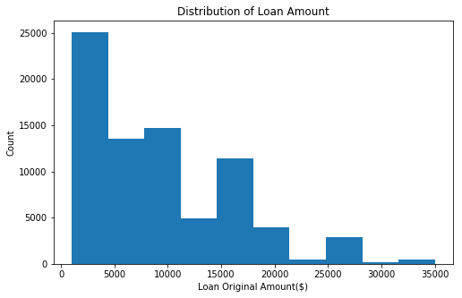

```python
plt.figure(figsize=[8, 5])
plt.hist(data = loan_data, x = 'LoanOriginalAmount')
plt.xlabel('Loan Original Amount($)')
plt.ylabel('Count')
plt.title('Distribution of Loan Amount');
```

> The distribution above is right skewed. Even though the histogram is dense, we can still tell that the loan amount with the highest frequency is within 1000 and 4000 dollars, while the highest amount of loan taken is around 35000.

> I will zoom into the histogram by increasing the number of bins in the next cells

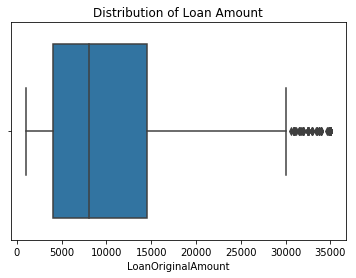

```python
sb.boxplot(loan_data['LoanOriginalAmount'])
plt.title('Distribution of Loan Amount');
```

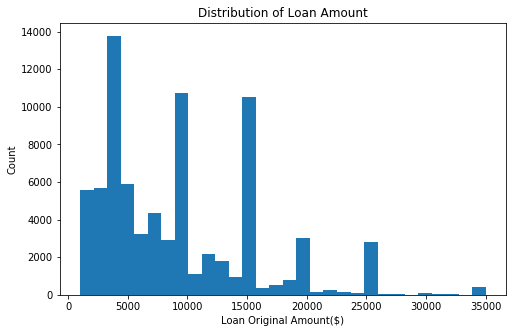

```python
plt.figure(figsize=[8, 5])
plt.hist(data = loan_data, x = 'LoanOriginalAmount', bins=30)
plt.xlabel('Loan Original Amount($)')
plt.ylabel('Count')
plt.title('Distribution of Loan Amount');
```

### Observations

As earlier observed the loan amount with the highest frequency is between $1000-4000. While 35000 is the highest loan taken out by a borrower. The histogram is still right skewed, but has a multimodal distribution.

### Question 2

The distribution of `BorrowerAPR`

### Visualization

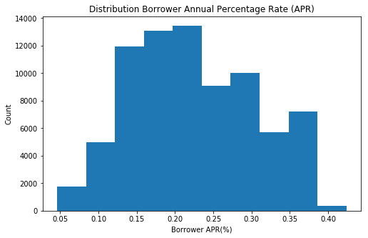

```python
plt.figure(figsize=[8, 5])
plt.hist(data = loan_data, x = 'BorrowerAPR')
plt.xlabel('Borrower APR(%)')
plt.ylabel('Count')
plt.title('Distribution Borrower Annual Percentage Rate (APR)');
```

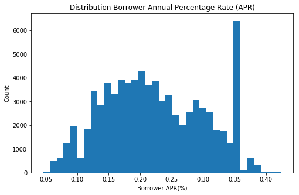

```python
plt.figure(figsize=[8, 5])
plt.hist(data = loan_data, x = 'BorrowerAPR', bins=35)
plt.xlabel('Borrower APR(%)')
plt.ylabel('Count')
plt.title('Distribution Borrower Annual Percentage Rate (APR)');
```

### Observations

The `BorrowerAPR` is the annual cost of a loan to a borrower which includes the `BorrowerRate` and the other costs that have accured on the load that year. I suspect the distribution will be similar to the distribution `BorrowerRate`

### Question 3

The distribution of `BorrowerRate`

### Visualization

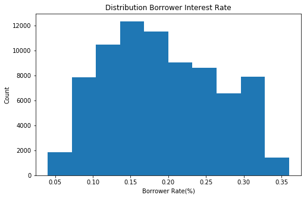

```python
plt.figure(figsize=[8, 5])
plt.hist(data = loan_data, x = 'BorrowerRate')
plt.xlabel('Borrower Rate(%)')
plt.ylabel('Count')
plt.title('Distribution Borrower Interest Rate');
```

At a glance, `BorrowerRate's` histogram seem to share similarities with `BorrowerAPR`. Next, zoom into the distribution

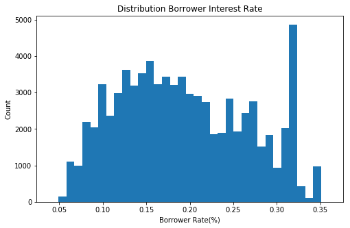

```python
plt.figure(figsize=[8, 5])
plt.hist(data = loan_data, x = 'BorrowerRate', bins=35)
plt.xlabel('Borrower Rate(%)')
plt.ylabel('Count')
plt.title('Distribution Borrower Interest Rate');
```

### Observations

Both histohrams do share a certain level of similarity, Let's view the side-by-side to further investigate the similarities.

### Question 4

The distribution of `BorrowerAPR` and `BorrowerRate`

### Visualization

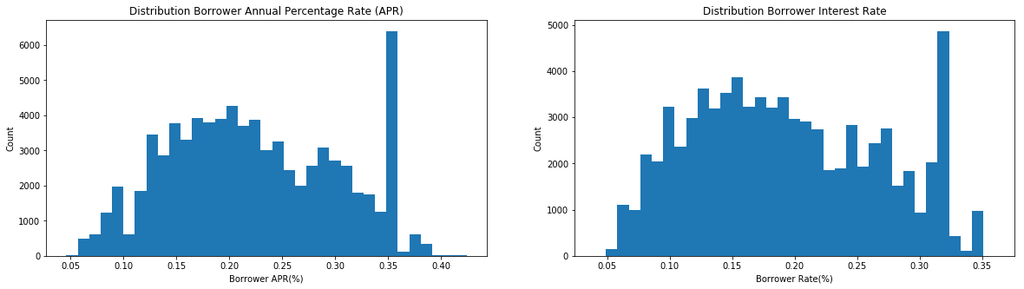

```python
plt.figure(figsize = [20, 5])

# histogram on left
# 1 row, 2 cols, subplot 1
plt.subplot(1, 2, 1)
plt.hist(data = loan_data, x = 'BorrowerAPR', bins=35)
plt.xlabel('Borrower APR(%)')
plt.ylabel('Count')
plt.title('Distribution Borrower Annual Percentage Rate (APR)');

# histogram on right
# 1 row, 2 cols, subplot 2
plt.subplot(1, 2, 2)
plt.hist(data = loan_data, x = 'BorrowerRate', bins=35)
plt.xlabel('Borrower Rate(%)')
plt.ylabel('Count')
plt.title('Distribution Borrower Interest Rate');
```

### Observations

The x-axis limit of `BorrowerAPR` is higher than `BorrowerRate`. This can be as a result of the addition chargeges that have been `BorroweRate` to get the `BorrowerAPR`. They might also share a positive correlation with each other.

### Question 5

The distribution of `MonthlyLoanPayment`

### Visualization

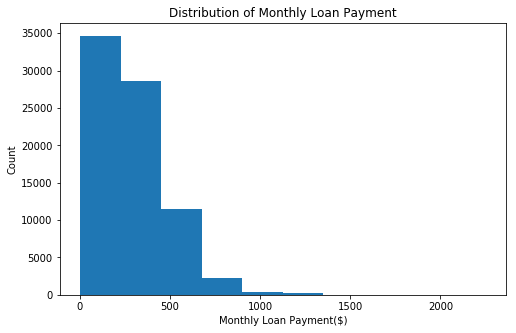

```python
plt.figure(figsize=[8, 5])
plt.hist(data = loan_data, x = 'MonthlyLoanPayment')
plt.xlabel('Monthly Loan Payment($)')
plt.ylabel('Count')
plt.title('Distribution of Monthly Loan Payment');
```

As a reult of the skeweness, outliers can be expected. Firther investigation in the following cells

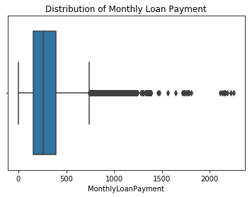

```python
sb.boxplot(loan_data['MonthlyLoanPayment'])
plt.title('Distribution of Monthly Loan Payment'); #checking for outliers
```

The box plot above has revealed a nimber of outliers, these will be revoved from the data

```python
loan_data.shape #original shape of data before removing the outliers
```

```
(77557, 23)
```

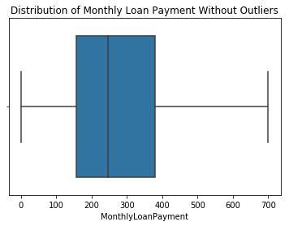

```python
data_new = loan_data[(loan_data['MonthlyLoanPayment']<700)]
sb.boxplot(data_new['MonthlyLoanPayment'])
plt.title('Distribution of Monthly Loan Payment Without Outliers');
```

```python
data_new.shape #shape of the data after removing outliers
```

```
(75100, 23)
```

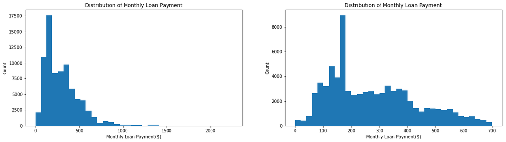

```python
plt.figure(figsize = [20, 5]) #setting the figure size

# histogram on left
# 1 row, 2 cols, subplot 1
plt.subplot(1, 2, 1) #data with outliers
plt.hist(data = loan_data, x = 'MonthlyLoanPayment', bins=35)
plt.xlabel('Monthly Loan Payment($)')
plt.ylabel('Count')
plt.title('Distribution of Monthly Loan Payment');

# histogram on right
# 1 row, 2 cols, subplot 2
plt.subplot(1, 2, 2) #data without outliers
plt.hist(data = data_new, x = 'MonthlyLoanPayment', bins=35)
plt.xlabel('Monthly Loan Payment($)')
plt.ylabel('Count')
plt.title('Distribution of Monthly Loan Payment');
```

### Observations

Viewing the original data and the cleaned data together, the skeweness has been taken care of and the distribution now looks more spread across the x-axis. While we had a unimodal distribution initially, the new distribution turned out to be a bimodal distribytion

### Question 6

The distribution of `DebtToIncomeRatio`

### Visualization

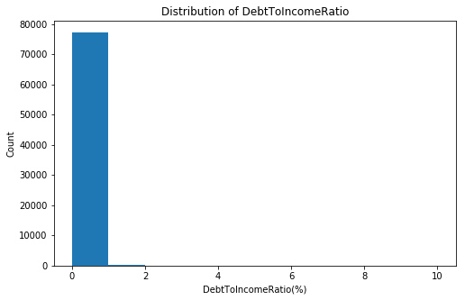

```python
plt.figure(figsize=[8, 5])
plt.hist(data = loan_data, x = 'DebtToIncomeRatio')
plt.xlabel('DebtToIncomeRatio(%)')
plt.ylabel('Count')
plt.title('Distribution of DebtToIncomeRatio');
```

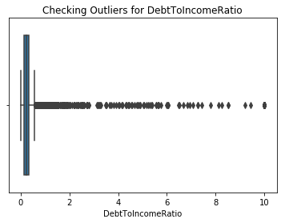

```python
sb.boxplot(loan_data['DebtToIncomeRatio'])
plt.title('Checking Outliers for DebtToIncomeRatio');
```

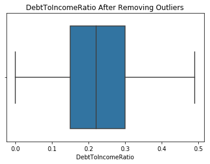

```python
data_new2 = loan_data[(loan_data['DebtToIncomeRatio']<0.5)]
sb.boxplot(data_new2['DebtToIncomeRatio'])
plt.title('DebtToIncomeRatio After Removing Outliers');
```

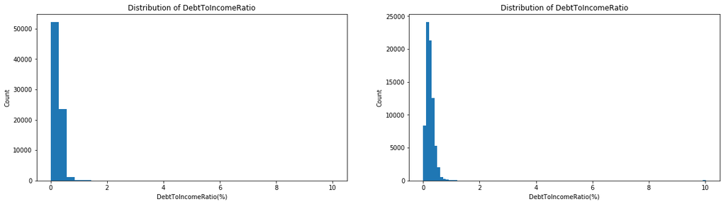

```python
plt.figure(figsize = [20, 5])


# histogram on left, data with outliers
# 1 row, 2 cols, subplot 1
plt.subplot(1, 2, 1)
plt.hist(data = loan_data, x = 'DebtToIncomeRatio', bins=35)
plt.xlabel('DebtToIncomeRatio(%)')
plt.ylabel('Count')
plt.title('Distribution of DebtToIncomeRatio');

# histogram on right, data without outliers
# 1 row, 2 cols, subplot 2
plt.subplot(1, 2, 2) #
plt.hist(data = data_new, x = 'DebtToIncomeRatio', bins=100)
plt.xlabel('DebtToIncomeRatio(%)')
plt.ylabel('Count')
plt.title('Distribution of DebtToIncomeRatio');
```

### Question 7

The distribution of `Term`

### Visualization

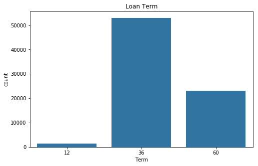

```python
base_color = sb.color_palette()[0] #setting bar colors

plt.figure(figsize=[8, 5])
sb.countplot(data=loan_data, x='Term', color=base_color) #plot bar chart
plt.title('Loan Term');
```

### Observations

`Term` is measured in months. From the chart above, while the longest term for loan is 60 months (5 year), most borrowers opt for 36 months (3 years)

### Question 8

Plot `LoanStatus`, `ProsperScore` and `ProsperRating (Alpha)` together to get an idea of each ordinal variable's distribution.

### Visualization

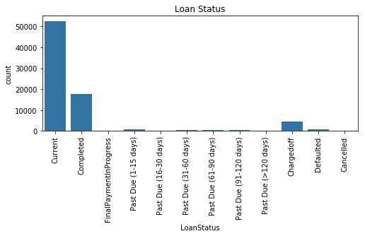

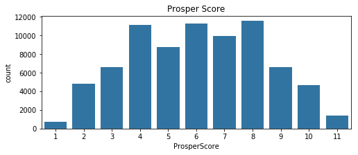

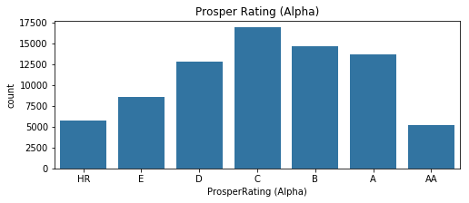

```python
plt.figure(figsize=[8,3]) # set display size
sb.countplot(data=loan_data, x='LoanStatus', color=base_color) # plot bars
plt.title('Loan Status')
plt.xticks(rotation=90) #rotate x-axis labels for better view
plt.show()

plt.figure(figsize=[8,3]) # set display size
sb.countplot(data=loan_data, x='ProsperScore', color=base_color) # plot bars
plt.title('Prosper Score')
plt.show()

plt.figure(figsize=[8,3]) # set display size
sb.countplot(data=loan_data, x='ProsperRating (Alpha)', color=base_color) # plot bars
plt.title('Prosper Rating (Alpha)')
plt.show()
```

### Observations

`ProsperRating (Alpha)` has a gaussian distribution, `LoanStatus` has one spike in its distribution, making it unimodal and `ProsperScore` has three spikes resulting in multimodal distribution. The loan status of over 50% of loan is still active, a number of borrowers have also either defaulted or has yet to pay back the loan before the due date.

### Question 9

What is the `Income Range` and `EmploymentStatus` of borrowers? Are there more high earners than there are low earners?

### Visualization

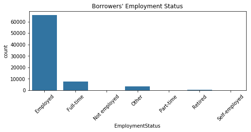

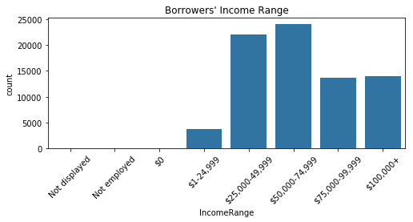

```python
plt.figure(figsize=[8,3])
plt.xticks(rotation=45) # rotate x-axis labels for better view
sb.countplot(data=loan_data, x='EmploymentStatus', color=base_color) # plot bars
plt.title("Borrowers' Employment Status")
plt.show()

plt.figure(figsize=[8,3])
plt.xticks(rotation=45) # rotate x-axis labels for better view
sb.countplot(data=loan_data, x='IncomeRange', color=base_color) # plot bars
plt.title("Borrowers' Income Range")
plt.show()
```

### Observations

About 90% of borrowers are employed and have taken out loans while unemployed ans self-employed people have not been able to take out any loans

### Question 10

Which quarter of the year do people take out loans most?

### Visualization

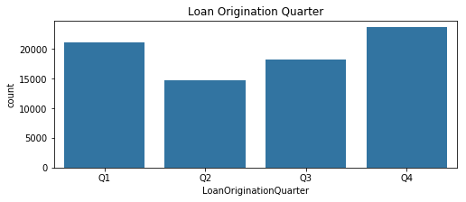

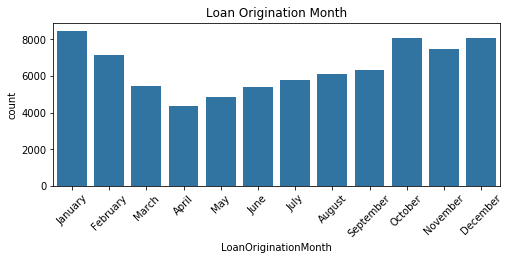

```python
plt.figure(figsize=[8,3])
sb.countplot(data=loan_data, x='LoanOriginationQuarter', color=base_color) #plot bars
plt.title('Loan Origination Quarter')
plt.show()

plt.figure(figsize=[8,3])
sb.countplot(data=loan_data, x='LoanOriginationMonth', color=base_color)
plt.title('Loan Origination Month')
plt.xticks(rotation=45) # rotate x-axis labels for better view
plt.show()
```

### Observations

Looking at the both charts above, most of the ;oan action occur at Q1 (January-March) and Q4 (October-December). Q1 has New Year's and is right before Easter while Q4 has Thansgiving and Christmas holidays. Could this be the reason why more people take out loans during these months?